# Introduction to Version Control

Marvin Ludwig

# git

- Version Control System
- Developed by Linus Torvalds to work on the Linux Kernel with mutliple people
- Mainly for Code, but useful for many other things

[figure not shown]

# Why Version Control?

- “forces” some good habits
  - structured thinking
  - structured working in small chunks
  - goal-oriented
- (supports Open-Source development)

# Get git

- https://git-scm.com/download/
- preinstalled on most GNU/Linux distributions
- GUI Versions available

[figure not shown]

# git Workflow

- Application with a learning curve
- Simple but easy to mess something up
- Core unit: **A repository**

```bash
git init    # to start
```

```bash
git status # to get infos

git add    # to add files to the tracking system

git commit # to define changed files as the new standard
```

# Git Branches - The Tree Model

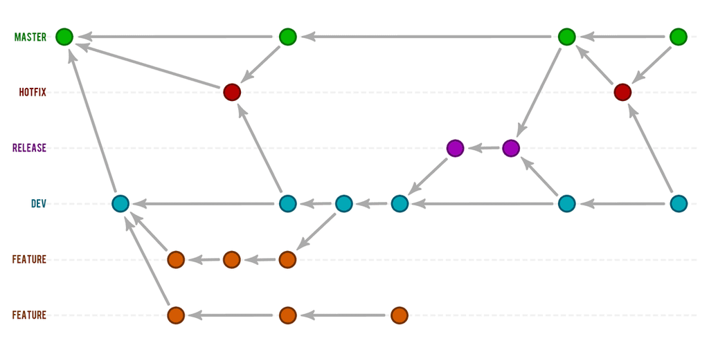

*https://bluecast.tech/wp-content/uploads/2019/09/git-switch-branch*

```bash
git branch # to create a new branch

git switch # to switch between branches

git merge  # to merge two branches together
```

# .gitignore

- exclude files and filetypes
- typical example for an R project:

```bash
.Rhistory
/data/
*.tif
```

# GitHub

- platform for code sharing
- smooth integration into the git workflow
- makes collaborations easy
- *“Developers Social Media”*
- scientific communication

# GitHub

- “Cloud storage” for git repositories
- Contains files, code, documentation, installation guide, (data)…

## Additional Features

- Wiki
- Issue - Tracker
- Automation
- …

# Github Related Commands

```bash
git remote    # to get infos about remote

git push      # to send commits to remote

git pull      # to download commits from remote
```

```bash
git clone     # to download a repository
```

## Further Actions

- Forking
- Pull requests

# Overview

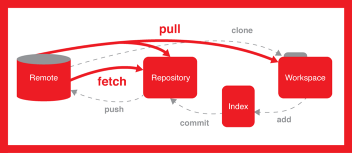

*https://miro.medium.com/max/700/1*9qX9F9MGsWKfcmgTOR9BPw.png*

# Rstudio Integration

Rstudio is a powerful user interface for git!

[figure not shown]

# Real World Example: R packages

https://github.com/HannaMeyer/CAST

Package Page created with `pkgdown`

```r
install.packages("CAST")

devtools::install_github(repo = "https://github.com/HannaMeyer/CAST")

remotes::install_github(repo = "https://github.com/HannaMeyer/CAST")
```

Package Page created with `pkgdown`: https://hannameyer.github.io/CAST

# Real World Example: Bugfix

There is a small Bug in the r-package `getSpatialData`

https://github.com/16EAGLE/getSpatialData

In the file `R/internal_clients.R` Line 40:

```r
# wrong:
lapply(uuid, function(x) content(.get(paste0(cred[3], "/odata/v1/Products('", x, "')/", field), cred[1], cred[2])))

# correct:
lapply(uuid, function(x) content(.get(paste0(cred[3], "odata/v1/Products('", x, "')/", field), cred[1], cred[2])))
```

**Which workflow do you propose?**

# Real World Example: Publications

> All computations were done in R (Version 4.0.2; [38]). All presented methods are provided as the R-package uavRmp (https://gisma.github.io/uavRmp/) and the Metashape Python Scripts (https://github.com/envima/MetashapeTools). - Ludwig et al. 2020

> The ELC10 dataset is available here: https://doi.org/10.5281/zenodo.4407051 JavaScript and R code to reproduce ELC10 is available here: https://github.com/NINAnor/ELC10 - Venter et al. 2021

# GitHub Pages

Github can serve webpages!

- markdown based
- syntax highlighting

Contents of docs/index.Rmd

```
---
title: "Introduction to Version Control"
author: "Marvin Ludwig"
output: html_document
theme: slate
layout: page
---

# Github Pages Demo

This is a demonstration for a simple but effective webpage on Github.

Click [here](presentation.html) for a presentation about git and Github.
```

# Include Large Files

- [DVC: Data Version Control](https://dvc.org/features)
- [LFS: Large File Storage](https://git-lfs.github.com/)

Track large files by including them with text-based pointers

```
outs:
- md5: 13ff4c5c6672752b90da533b408d0024.dir
  size: 1416965813
  nfiles: 13
  path: data/sentinel2
```

# Online Learning Ressources

[Beginner’s Guide to Git and Github](https://morioh.com/p/44ff44c19c6e)

[Youtube Video: University lecture with comprehensive technical explanation](https://www.youtube.com/watch?v=2sjqTHE0zok)

[Official Github Ressources: Quickstart Guide](https://docs.github.com/en/github/getting-started-with-github/quickstart)